# **Algoritma dan Pemrograman**

Pertemuan 11-12: Fungsi, Prosedur, Rekursif

Muhammad Fadil

2026-05-06

# 1 CPL, CMPK, dan SUB-CMPK

**CPL:** Mampu melakukan pengelolaan dan analisis data menggunakan teknik statistik dengan bantuan perangkat lunak.

**CMPK:** Mahasiswa mampu menerapkan teknik pemrograman dalam menyelesaikan masalah pemrograman.

**SUB-CMPK:** Mahasiswa mampu mengimplementasikan fungsi, prosedur, dan rekursi dalam pemrograman (CPMK-3).

# 2 Fungsi

Fungsi dalam R adalah blok kode yang menerima input (argumen), memproses data, dan mengembalikan nilai secara eksplisit maupun implisit. Di R, nilai kembalian adalah ekspresi terakhir yang dievaluasi, atau menggunakan return() secara eksplisit. Fungsi adalah objek kelas satu (first-class object) — bisa disimpan dalam variabel, diteruskan sebagai argumen, atau dikembalikan oleh fungsi lain.

## 2.1 Struktur penulisan Fungsi dalam R

### 2.1.1 Fungsi tanpa parameter

```r
nama_fungsi <- function(){
  return()
}
```

### 2.1.2 Fungsi dengan parameter

```r
nama_fungsi <- function(parameter){
  return(parameter)
}
```

### 2.1.3 Fungsi dengan parameter default

```r
nama_fungsi <- function(parameter = 'Ini Contoh Fungsi'){
  return(parameter)
}
```

## 2.2 Contoh Fungsi

### 2.2.1 Contoh 1

```r
# Struktur dasar fungsi
nama_fungsi <- function(parameter1, parameter2) {
  hasil <- parameter1 + parameter2
  return(hasil)
}

# Fungsi menghitung luas lingkaran
luas_lingkaran <- function(r) {
  pi * r^2
}

# Fungsi dengan parameter default
pesan <- function(nama, sapaan = "Halo") {
  paste(sapaan, nama)
}
```

Cara pemanggilan fungsinya:

```r
luas_lingkaran(7)
```

```
## [1] 153.938
```

```r
pesan("Ani")
```

```
## [1] "Halo Ani"
```

```r
pesan("Ali", "Selamat pagi")
```

```
## [1] "Selamat pagi Ali"
```

### 2.2.2 Contoh 2

Jika kita ingin mengambil beberapa nilai dari fungsi tersebut, maka `return`-nya (pengembaliannya) disimpan dalam bentuk list, kemudian list tersebut yang di kembalikan.

```r
statistik <- function(x) {
  list(
    rata2  = mean(x),
    median = median(x),
    sd     = sd(x),
    n      = length(x)
  )
}

data <- c(10, 20, 30, 40, 50)
hasil <- statistik(data)
hasil
```

```
## $rata2
## [1] 30
##
## $median
## [1] 30
##
## $sd
## [1] 15.81139
##
## $n
## [1] 5
```

```r
hasil$rata2
```

```
## [1] 30
```

```r
hasil$sd
```

```
## [1] 15.81139
```

### 2.2.3 Contoh Kasus-1

Program Konversi suhu

```r
konversi_suhu <- function(celsius) {
  list(
    fahrenheit = celsius * 9/5 + 32,
    kelvin     = celsius + 273.15
  )
}

suhu_air_didih <- konversi_suhu(100)
suhu_air_didih$fahrenheit
```

```
## [1] 212
```

```r
suhu_air_didih$kelvin
```

```
## [1] 373.15
```

### 2.2.4 Contoh Kasus-2

Program transformasi data (transformasi max-min)

```r
normalisasi <- function(x) {
  (x - min(x)) / (max(x) - min(x))
}

nilai_ujian <- c(55, 70, 80, 90, 100)
normalisasi(nilai_ujian)
```

```
## [1] 0.0000000 0.3333333 0.5555556 0.7777778 1.0000000
```

# 3 Prosedur

Prosedur adalah fungsi yang dijalankan untuk efek samping (side effect) — mencetak ke konsol, menyimpan file, membuat plot, atau memodifikasi lingkungan — bukan untuk menghasilkan nilai kembalian. Dalam R tidak ada kata kunci khusus untuk prosedur; prosedur ditulis sebagai fungsi biasa yang biasanya mengembalikan invisible(NULL) atau tidak ada return eksplisit. Prosedur dipanggil karena apa yang dilakukannya, bukan nilai yang dikembalikannya.

## 3.1 Struktur penulisan Prosedur dalam R

### 3.1.1 Prosedur tanpa parameter

```r
nama_prosedur <- function(){
  # code
}
```

### 3.1.2 Prosedur dengan parameter

```r
nama_prosedur <- function(parameter){
  # code
}
```

### 3.1.3 Prosedur dengan parameter default

```r
nama_prosedur <- function(parameter = 'Ini Contoh Prosedur'){
  # code
}
```

## 3.2 Contoh program Prosedur

### 3.2.1 Contoh 1

Prosedur mencetak informasi mahasiswa

```r
mhs_info <- function(nama, NIM) {
  cat("=== Informasi Mahasiswa ===\n")
  cat("Nama  :", nama, "\n")
  cat("NIM   :", NIM, "\n")
}

mhs_info("Ani", 85)
```

```
## === Informasi Mahasiswa ===
## Nama  : Ani
## NIM   : 85
```

### 3.2.2 Contoh 2

Prosedur mengubah variabel di environment luar

```r
counter <- 0 #env global

tambah_counter <- function(n = 1) {
  counter <<- counter + n  # memodifikasi env global
  cat("Counter sekarang:", counter, "\n")
}

tambah_counter()   # Counter sekarang: 1
```

```
## Counter sekarang: 1
```

```r
tambah_counter(5)  # Counter sekarang: 6
```

```
## Counter sekarang: 6
```

## 3.3 Contoh Kasus

### 3.3.1 Kasus 1

Tim data engineer membutuhkan prosedur standar untuk menyimpan dataframe ke file CSV dengan nama berdasarkan tanggal.

```r
simpan_csv <- function(df, nama_file) {
  tanggal <- format(Sys.Date(), "%Y%m%d")
  nama_lengkap <- paste0(nama_file, "_", tanggal, ".csv")
  write.csv(df, nama_lengkap, row.names = FALSE)
  cat("File disimpan:", nama_lengkap, "\n")
  cat("Jumlah baris:", nrow(df), "\n")
  invisible(NULL)
}

simpan_csv(iris, "data_iris")
```

```
## File disimpan: data_iris_20260506.csv
## Jumlah baris: 150
```

### 3.3.2 Kasus 2

Membuat prosedur: histogram standar dengan garis rata-rata.

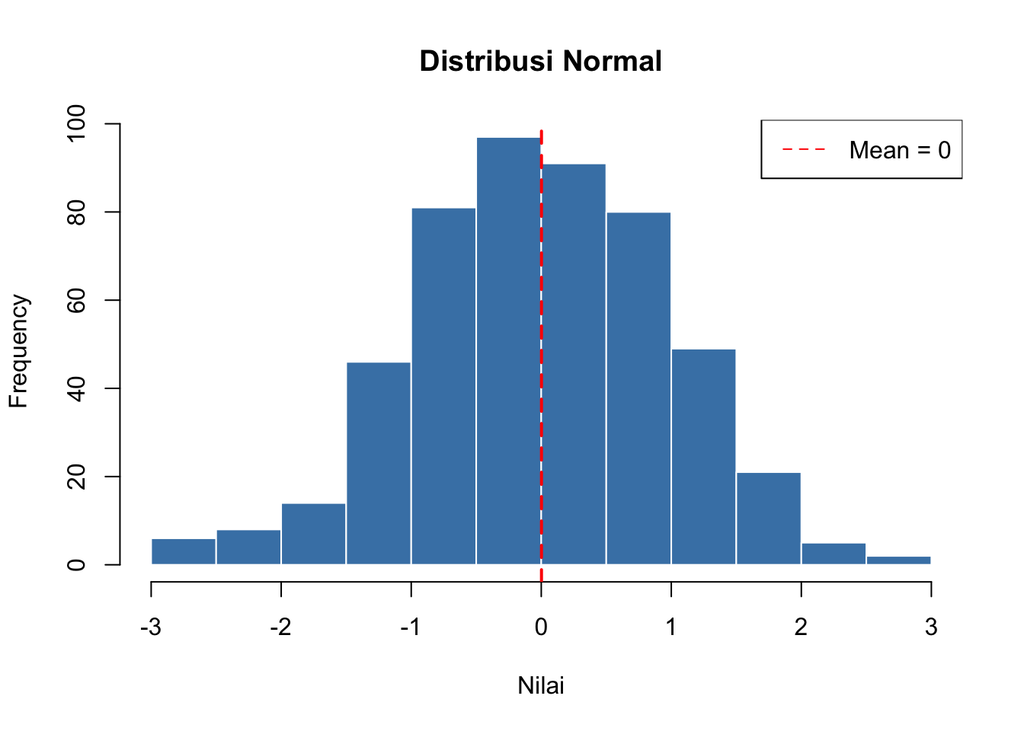

```r
plot_distribusi <- function(data, judul = "Distribusi Data") {
  hist(data,
    main  = judul,
    xlab  = "Nilai",
    col   = "steelblue",
    border = "white"
  )
  abline(v = mean(data), col = "red", lwd = 2, lty = 2)
  legend("topright",
    legend = paste("Mean =", round(mean(data), 2)),
    col = "red", lty = 2
  )
  invisible(NULL)
}

plot_distribusi(rnorm(500), "Distribusi Normal")
```

# 4 Rekursif

Rekursi adalah teknik di mana sebuah fungsi memanggil dirinya sendiri untuk menyelesaikan submasalah yang semakin kecil. Setiap fungsi rekursif di R wajib memiliki dua bagian: base case (kondisi berhenti) dan recursive case (pemanggilan diri menuju base case). R mendukung rekursi penuh, namun memiliki batas kedalaman stack default sekitar 1000 level.

## 4.1 Contoh

### 4.1.1 Contoh 1

Program faktorial

```r
faktorial <- function(n) {
  # Base case
  if (n == 0 || n == 1) return(1)

  n * faktorial(n - 1) # Recursive case
}

faktorial(5)
```

```
## [1] 120
```

```r
faktorial(10)
```

```
## [1] 3628800
```

### 4.1.2 Contoh 2

Program Fibonacci

```r
fibonacci <- function(n) {
  if (n <= 1) return(n)
  fibonacci(n - 1) + fibonacci(n - 2)
}

sapply(0:9, fibonacci)
```

```
##  [1]  0  1  1  2  3  5  8 13 21 34
```

### 4.1.3 Contoh 3

Program list bersarang (tree traversal)

```r
hitung_elemen <- function(lst) {
  total <- 0
  for (item in lst) {
    if (is.list(item)) {
      total <- total + hitung_elemen(item)  # rekursif
    } else {
      total <- total + 1
    }
  }
  return(total)
}

pohon <- list(1, 2, list(3, 4, list(5, 6)))
hitung_elemen(pohon)
```

```
## [1] 6
```

## 4.2 Contoh Kasus

### 4.2.1 Kasus 1

Binary search rekursif

```r
binary_search <- function(vec, target, kiri = 1, kanan = length(vec)) {
  # Base case: tidak ditemukan
  if (kiri > kanan) return(-1)

  tengah <- floor((kiri + kanan) / 2)

  if (vec[tengah] == target) return(tengah)
  if (vec[tengah] <  target) return(binary_search(vec, target, tengah + 1, kanan))
  return(binary_search(vec, target, kiri, tengah - 1))
}

data <- c(2, 5, 8, 12, 16, 23, 38, 56, 72, 91)
binary_search(data, 23)
```

```
## [1] 6
```

```r
binary_search(data, 99)
```

```
## [1] -1
```

### 4.2.2 Kasus 3

Menghitung jumlah semua digit dalam sebuah bilangan bulat, berguna untuk validasi checksum.

```r
jumlah_digit <- function(n) {
  n <- abs(n)               # tangani bilangan negatif
  if (n < 10) return(n)     # base case: satu digit
  (n %% 10) + jumlah_digit(n %/% 10)
}

jumlah_digit(1234)
```

```
## [1] 10
```

```r
jumlah_digit(9876)
```

```
## [1] 30
```

Catatan:

- Hati-hati dengan rekursi dalam di R — batas default stack adalah ~1000 level. Gunakan `options(expressions = 5e5)` untuk memperbesar, atau pertimbangkan iterasi / `Recall()` untuk kasus dalam.
- Untuk data besar, fungsi seperti `Reduce()`, `rapply()`, dan `Map()` di R sering menjadi alternatif rekursi yang lebih efisien secara memori.

# 5 Evaluasi efisiensi

Evaluasi efisiensi rekursi mencakup dua dimensi utama: kompleksitas waktu (time complexity) — seberapa cepat fungsi bekerja seiring input bertambah, dan kompleksitas ruang (space complexity) — seberapa banyak memori yang dikonsumsi, terutama oleh call stack. Rekursi tidak selalu lambat, tetapi penggunaan yang tidak tepat dapat menyebabkan ledakan komputasi eksponensial.

## 5.1 Kompleksitas waktu — perbandingan langsung

Salah satu contoh nya adalah program Fibonacci. Fibonacci adalah contoh paling jelas mengapa implementasi rekursi mempengaruhi efisiensi secara drastis.

- **Rekursi naif (O(2^n))**: Setiap panggilan menghasilkan dua sub-panggilan. Untuk fib(40), fungsi dipanggil lebih dari 300 juta kali. Banyak nilai dihitung ulang berkali-kali.
- **Rekursi + memoization (O(n))**: Setiap nilai hanya dihitung sekali lalu disimpan. Untuk fib(40), hanya 40 panggilan unik yang dilakukan.
- **Iteratif (O(n))**: Loop sederhana tanpa overhead pemanggilan fungsi dan tanpa penggunaan call stack. Paling hemat memori.
- **Tail recursion (O(n))**: Rekursi ekor — pemanggilan rekursif adalah operasi terakhir. Beberapa compiler/interpreter mengoptimalkannya menjadi loop otomatis.

## 5.2 Kompleksitas ruang — call stack

Setiap pemanggilan rekursif menambah satu stack frame ke call stack. Rekursi dengan kedalaman n berarti n frame aktif sekaligus di memori.

## 5.3 Solusi peningkatan efisiensi di R

Contoh: Memoization dengan memoise package

```r
library('memoise') ## if error, run: install.packages("memoise")

fib_naif <- function(n) {
  if (n <= 1) return(n)
  fib_naif(n-1) + fib_naif(n-2)
}

# Bungkus dengan memoise — otomatis cache hasil
fib_cepat <- memoise(fib_naif)

system.time(fib_naif(30))
```

```
##    user  system elapsed
##   1.484   0.048   2.484
```

```r
system.time(fib_cepat(30))
```

```
##    user  system elapsed
##   1.624   0.061   3.866
```

Memoization manual dengan environment

```r
cache <- new.env(hash = TRUE)

fib_memo <- function(n) {
  key <- as.character(n)
  if (exists(key, envir = cache)) return(get(key, envir = cache))
  if (n <= 1) { assign(key, n, envir = cache); return(n) }
  hasil <- fib_memo(n-1) + fib_memo(n-2)
  assign(key, hasil, envir = cache)
  hasil
}

fib_memo(50)
```

```
## [1] 12586269025
```

Tail recursion — akumulator menghindari tumpukan dalam

```r
# Rekursi ekor: pemanggilan rekursif adalah operasi terakhir
faktorial_tail <- function(n, acc = 1) {
  if (n <= 1) return(acc)
  faktorial_tail(n - 1, n * acc)  # akumulator membawa hasilnya
}

faktorial_tail(10)
```

```
## [1] 3628800
```

```r
faktorial_tail(15)
```

```
## [1] 1.307674e+12
```

Perbesar batas rekursi R dengan `options()`

```r
# Default R: ~1000 level rekursi
getOption("expressions")  # 5000
```

```
## [1] 5000
```

```r
# Perbesar untuk rekursi dalam
options(expressions = 500000)

# Atau gunakan Recall() — lebih portable
faktorial_recall <- function(n) {
  if (n <= 1) return(1)
  n * Recall(n - 1)  # Recall() aman saat fungsi di-rename
}
```

## 5.4 Kapan pakai rekursi vs iterasi

| Situasi | Rekursi | Iterasi | Rekomendasi |
| --- | --- | --- | --- |
| Struktur pohon / graph | Sangat alami | Perlu stack manual | Rekursi |
| Faktorial / deret sederhana | Elegan tapi boros | Hemat, cepat | Iterasi |
| Fibonacci | O(2ⁿ) jika naif | O(n) selalu | Memo / Iterasi |
| Divide & conquer (merge sort) | Lebih intuitif | Kompleks ditulis | Rekursi |
| Input sangat besar (n > 10.000) | Risiko stack overflow | Aman, stabil | Iterasi |
| Backtracking (maze, puzzle) | Jauh lebih mudah | Sangat sulit | Rekursi |

**Ket:**

- Rekursi efisien ketika: masalah bersifat rekursif secara alami (pohon, graf, backtracking), dikombinasikan dengan memoization, dan kedalaman rekursi terbatas dan dapat diprediksi.
- Rekursi tidak efisien ketika: ada submasalah yang tumpang tindih tanpa memoization (seperti Fibonacci naif), input sangat besar sehingga stack bisa habis, atau solusi iteratif sama mudahnya ditulis.